# Análisis Exploratorio de Datos de los Alquileres Vacacionales en Lisboa

## 1. Introducción

Este proyecto forma parte de la asignatura *R for Data Science* y se centra en el análisis del mercado de alojamientos turísticos de Airbnb en **el distrito Lisboa, Portugal**. El objetivo principal es transformar los datos originales en información útil que permita tomar decisiones de inversión fundamentadas.

El análisis se desarrolla desde la perspectiva de **un analista del ayuntamiento**, con el propósito de evaluar la distribución y concentración del mercado de alojamientos turísticos en Lisboa. Para ello, se estudiará quién controla la oferta, el grado de cumplimiento de las licencias turísticas y las zonas donde la actividad de Airbnb podría generar una mayor presión sobre el mercado de la vivienda residencial.

Para ello, se utilizará el lenguaje de programación R, aplicando diferentes técnicas de limpieza, transformación, exploración y visualización de datos. Se analizarán variables como la ubicación de los alojamientos, el tipo de propiedad, los precios y otras características relevantes del mercado.

Finalmente, el objetivo es identificar patrones y posibles oportunidades de inversión que permitan formular recomendaciones basadas en datos y facilitar una toma de decisiones más informada.

## 2. Importación de los datasets y librerías

Para llevar a cabo estas tareas será necesario cargar las librerías y los datasets objeto de análisis

```r
# Importing libraries
library(readr)
library(tidyverse)
library(janitor)
```

```r
library(skimr)

library(ggplot2)
library(scales)
library(forcats)

# Importing csv
listings <- read_csv("./listings.csv")
calendar <- read_csv("./calendar.csv")
neighbourhoods <- read_csv("./neighbourhoods.csv")
reviews <- read_csv("./reviews.csv")
# Viewing the results
glimpse(listings)
```

```
## Rows: 24,876
## Columns: 90
## $ id                                           <dbl> 6499, 25659, 29396, 29720…
## $ listing_url                                  <chr> "https://www.airbnb.com/r…
## $ scrape_id                                    <dbl> 2.026062e+13, 2.026062e+1…
## $ last_scraped                                 <date> 2026-07-02, 2026-06-26, …
## $ source                                       <chr> "city scrape", "city scra…
## $ name                                         <chr> "Belém 1 Bedroom Historic…
## $ description                                  <chr> "This apartment is all ab…
## $ neighborhood_overview                        <lgl> NA, NA, NA, NA, NA, NA, N…
## $ picture_url                                  <chr> "https://a0.muscache.com/…
## $ host_id                                      <dbl> 14455, 107347, 126415, 12…
## $ host_url                                     <chr> "https://www.airbnb.com/u…
## $ host_profile_id                              <dbl> 1.462507e+18, 1.462510e+1…
## $ host_profile_url                             <chr> "https://www.airbnb.com/u…
```

[output cut: 77 more lines]

```r
glimpse(calendar)
```

```
## Rows: 9,092,881
## Columns: 5
## $ listing_id     <dbl> 6499, 6499, 6499, 6499, 6499, 6499, 6499, 6499, 6499, 6…
## $ date           <date> 2026-07-02, 2026-07-03, 2026-07-04, 2026-07-05, 2026-0…
## $ available      <lgl> FALSE, FALSE, FALSE, FALSE, FALSE, FALSE, FALSE, FALSE,…
## $ minimum_nights <dbl> 3, 3, 3, 3, 3, 3, 3, 3, 3, 3, 3, 3, 3, 3, 3, 3, 3, 3, 3…
## $ maximum_nights <dbl> 1125, 1125, 1125, 1125, 1125, 1125, 1125, 1125, 1125, 1…
```

```r
glimpse(neighbourhoods)
```

```
## Rows: 134
## Columns: 2
## $ neighbourhood_group <chr> "Alenquer", "Alenquer", "Alenquer", "Alenquer", "A…
## $ neighbourhood       <chr> "Abrigada e Cabanas de Torres", "Aldeia Galega da …
```

```r
glimpse(reviews)
```

```
## Rows: 1,886,932
## Columns: 6
## $ listing_id    <dbl> 6499, 6499, 6499, 6499, 6499, 6499, 137461, 137461, 1374…
## $ id            <dbl> 1.887922e+07, 2.107412e+07, 2.470400e+07, 3.789494e+07, …
## $ date          <date> 2014-09-02, 2014-10-11, 2015-01-02, 2015-07-11, 2015-08…
## $ reviewer_id   <dbl> 17027029, 7661611, 20348870, 34762351, 39438424, 2923523…
## $ reviewer_name <chr> "Simone", "Cláudio", "Rodrigo", "Blandine", "Mirjana", "…
## $ comments      <chr> "Ola Bruno,\r<br/>\r<br/>Tive um mes Fantástico em seu a…
```

## 3. Limpieza de los datos

Antes de manipular los datos será necesario limpiar y procesar algunas columnas cuya información viene incompleta o mal formateada. Realizaremos las siguientes conversiones.

### Estandarización de nombres y eliminación de duplicados; eliminación de columnas sin ningún valor

```r
# Standardize column names
listings <- listings |> clean_names()
calendar <- calendar |> clean_names()
neighbourhoods <- neighbourhoods |> clean_names()
reviews <- reviews |> clean_names()

# Check missing values
listings |> summarise(across(everything(), ~sum(is.na(.x))))
```

```
## # A tibble: 1 × 90
##      id listing_url scrape_id last_scraped source  name description
##   <int>       <int>     <int>        <int>  <int> <int>       <int>
## 1     0           0         0            0      0     0         613
## # ℹ 83 more variables: neighborhood_overview <int>, picture_url <int>,
## #   host_id <int>, host_url <int>, host_profile_id <int>,
## #   host_profile_url <int>, host_name <int>, host_since <int>,
## #   hosts_time_as_user_years <int>, hosts_time_as_user_months <int>,
## #   hosts_time_as_host_years <int>, hosts_time_as_host_months <int>,
## #   host_location <int>, host_about <int>, host_response_time <int>,
## #   host_response_rate <int>, host_acceptance_rate <int>, …
```

```r
# Check duplicated listings
sum(duplicated(listings$id))
```

```
## [1] 0
```

```r
# Remove duplicated listings
listings <- listings |>
  distinct(id, .keep_all = TRUE)

# Check dimensions
dim(listings)
```

```
## [1] 24876    90
```

No hay líneas duplicadas. Sin embargo, hay algunas columnas cuyo número de valores N/A es idéntico al número de registros del dataset. Dado que estas columnas no serán útiles para nada en nuestro análisis, se eliminarán.

```r
# Remove columns where all values are NA
tidy_listings <- listings |>
  select(where(~ !all(is.na(.))))

# Count missing values in each remaining column
tidy_listings |>
  summarise(across(everything(), ~ sum(is.na(.x))))
```

```
## # A tibble: 1 × 79
##      id listing_url scrape_id last_scraped source  name description picture_url
##   <int>       <int>     <int>        <int>  <int> <int>       <int>       <int>
## 1     0           0         0            0      0     0         613          14
## # ℹ 71 more variables: host_id <int>, host_url <int>, host_profile_id <int>,
## #   host_profile_url <int>, host_name <int>, hosts_time_as_user_years <int>,
## #   hosts_time_as_user_months <int>, hosts_time_as_host_years <int>,
## #   hosts_time_as_host_months <int>, host_location <int>, host_about <int>,
## #   host_is_superhost <int>, host_picture_url <int>, host_listings_count <int>,
## #   host_verifications <int>, host_has_profile_pic <int>,
## #   host_identity_verified <int>, neighbourhood_cleansed <int>, …
```

También se eliminarán columnas que no aportan información relevante en el análisis, como identificadores técnicos, datos de *scrapeo*, URLs, descripciones e información redundante.

```r
# Remove unnecessary columns
tidy_listings <- tidy_listings |>
  select(
    -any_of(c(
      # URLs and images
      "listing_url",
      "picture_url",
      "host_url",
      "host_profile_url",
      "host_picture_url",
      "host_thumbnail_url",

      # Technical identifiers
      "scrape_id",
      "host_profile_id",

      # Descriptive text
      "description",
      "neighborhood_overview",
      "host_about",
      "host_verifications",

      # Additional price information
      "price_quote_raw",
      "price_quote_total_price",
      "price_quote_checkin_date",
      "price_quote_checkout_date",

      # Redundant stay variables
      "minimum_minimum_nights",
      "maximum_minimum_nights",
      "minimum_maximum_nights",
      "maximum_maximum_nights"
    ))
  )

# Check remaining dimensions
dim(tidy_listings)
```

```
## [1] 24876    61
```

```r
# View remaining variables
glimpse(tidy_listings)
```

```
## Rows: 24,876
## Columns: 61
## $ id                                           <dbl> 6499, 25659, 29396, 29720…
## $ last_scraped                                 <date> 2026-07-02, 2026-06-26, …
## $ source                                       <chr> "city scrape", "city scra…
## $ name                                         <chr> "Belém 1 Bedroom Historic…
## $ host_id                                      <dbl> 14455, 107347, 126415, 12…
## $ host_name                                    <chr> "Bruno", "Ellie", "Mónica…
## $ hosts_time_as_user_years                     <dbl> 17, 16, 16, 16, 16, 16, 1…
## $ hosts_time_as_user_months                    <dbl> 2, 2, 1, 1, 1, 0, 0, 9, 0…
## $ hosts_time_as_host_years                     <dbl> 15, 15, 15, 15, 15, 15, 1…
## $ hosts_time_as_host_months                    <dbl> 6, 5, 5, 5, 5, 5, 5, 5, 0…
## $ host_location                                <chr> "Brussels, Belgium", "Lis…
## $ host_is_superhost                            <lgl> FALSE, TRUE, FALSE, TRUE,…
## $ host_listings_count                          <dbl> 1, 1, 1, 1, 2, 2, 5, 9, 7…
```

[output cut: 48 more lines]

### Limpieza de los precios

El dataset contiene diferentes variables relacionadas con el precio de los alojamientos. Para el análisis, se utilizará price_quote_price_per_night, ya que representa el precio por noche. Por ello, se eliminará la columna original price y se renombrará price_quote_price_per_night como price. Finalmente, se convertirán sus valores a formato numérico, eliminando los símbolos monetarios sin realizar ninguna conversión de divisa.

```r
# Remove old price column and rename price_quote_price_per_night
tidy_listings <- tidy_listings |>
  select(-price) |>
  rename(price = price_quote_price_per_night)

# Convert price to numeric if necessary
tidy_listings <- tidy_listings |>
  mutate(price = parse_number(as.character(price)))

# Check results
tidy_listings |>
  select(price) |>
  filter(!is.na(price))
```

```
## # A tibble: 22,636 × 1
##     price
##     <dbl>
##  1   90.7
##  2  109.
##  3  122
##  4 1096
##  5  120.
##  6   80
##  7  109
##  8   95
##  9  221
## 10   95.3
## # ℹ 22,626 more rows
```

```r
listings |>
  group_by(no_availability = availability_365 == 0) |>
  summarise(share_na_price = mean(is.na(price)), n = n())
```

```
## # A tibble: 2 × 3
##   no_availability share_na_price     n
##   <lgl>                    <dbl> <int>
## 1 FALSE                   0.0314 23368
## 2 TRUE                    0.999   1508
```

Al análisis ayudará también crear una variable de **price_per_person** que divida el precio por noche de la oferta por el número de personas capaces de reservarlo.

```r
tidy_listings <- tidy_listings |>
  mutate(
    price_per_person = if_else(
      !is.na(accommodates) & accommodates > 0,
      price / accommodates,
      NA_real_
    )
  )
```

### Limpieza y tratamiento de fechas

Ahora se convertirán las fechas del dataset para asegurar que los campos fecha tienen un formato homogéneo

```r
# Convert dates
listings <- listings |>
  mutate(
    first_review = as.Date(first_review),
    last_review = as.Date(last_review),
    last_scraped = as.Date(last_scraped),
  )
```

### Tratamiento de *Bathroom text* y *baths*

```r
listings |> count(bathrooms_text, sort = TRUE) |> head(n= Inf)
```

```
## # A tibble: 49 × 2
##    bathrooms_text     n
##    <chr>          <int>
##  1 1 bath         12464
##  2 2 baths         3515
##  3 1 private bath  1939
##  4 1 shared bath   1605
##  5 2 shared baths  1081
##  6 3 baths          768
##  7 1.5 baths        741
##  8 2.5 baths        561
##  9 3 shared baths   349
## 10 0 baths          276
## # ℹ 39 more rows
```

Se puede ver que el tratamiento del campo _baths y de *Bathroom_text* es un poco ambiguo, ya que no deja claras las características del baño. Se estandarizarán estas dos columnas con nuevos campos:

```r
tidy_listings <- tidy_listings |>
  mutate(
    bathrooms = parse_number(
      str_replace(
        bathrooms_text,
        regex("half-?bath", ignore_case = TRUE),
        "0.5"
      )
    ),
    bathrooms_shared = str_detect(bathrooms_text, "shared")
  )

tidy_listings |>
  count(bathrooms, bathrooms_shared, sort = TRUE) |>
  head(n= Inf)
```

```
## # A tibble: 46 × 3
##    bathrooms bathrooms_shared     n
##        <dbl> <lgl>            <int>
##  1       1   FALSE            14403
##  2       2   FALSE             3515
##  3       1   TRUE              1605
##  4       2   TRUE              1081
##  5       3   FALSE              768
##  6       1.5 FALSE              741
##  7       2.5 FALSE              561
##  8       3   TRUE               349
##  9       0   FALSE              276
## 10       1.5 TRUE               253
## # ℹ 36 more rows
```

### Tratamiento de *amenities*

*Amenities* es un campo cuyas entradas son listas de comodidades (como bien dice su nombre). Los campos lista son incómodos y difíciles de tratar/visualizar. Por ello se adaptará este campo en múltiples columnas. Para generar resultados más significativos eliminaremos las amenities con un conteo menor a 5000. Mantendremos esta tabla separada del listado.

```r
amenities <- tidy_listings |>
  select(id, amenities) |>
  mutate(amenities = str_remove_all(amenities, '[\\[\\]"]')) |>
  separate_rows(amenities, sep = ", ") |>
  add_count(amenities) |>
  filter(n >= 5000) |>
  select(-n)

# We drop amenities from tidy_listings
tidy_listings <- tidy_listings |>
  select(-amenities)

amenities |> count(amenities, sort = TRUE) |> head(n = Inf)
```

```
## # A tibble: 49 × 2
##    amenities                 n
##    <chr>                 <int>
##  1 Wifi                  22883
##  2 Kitchen               22589
##  3 Hot water             20870
##  4 Hair dryer            20136
##  5 Dishes and silverware 19289
##  6 Cooking basics        18685
##  7 Bed linens            18592
##  8 Hangers               18589
##  9 Iron                  18478
## 10 Essentials            18319
## # ℹ 39 more rows
```

El dataset resultante es el siguiente

```r
glimpse(tidy_listings)
```

```
## Rows: 24,876
## Columns: 61
## $ id                                           <dbl> 6499, 25659, 29396, 29720…
## $ last_scraped                                 <date> 2026-07-02, 2026-06-26, …
## $ source                                       <chr> "city scrape", "city scra…
## $ name                                         <chr> "Belém 1 Bedroom Historic…
## $ host_id                                      <dbl> 14455, 107347, 126415, 12…
## $ host_name                                    <chr> "Bruno", "Ellie", "Mónica…
## $ hosts_time_as_user_years                     <dbl> 17, 16, 16, 16, 16, 16, 1…
## $ hosts_time_as_user_months                    <dbl> 2, 2, 1, 1, 1, 0, 0, 9, 0…
## $ hosts_time_as_host_years                     <dbl> 15, 15, 15, 15, 15, 15, 1…
## $ hosts_time_as_host_months                    <dbl> 6, 5, 5, 5, 5, 5, 5, 5, 0…
## $ host_location                                <chr> "Brussels, Belgium", "Lis…
## $ host_is_superhost                            <lgl> FALSE, TRUE, FALSE, TRUE,…
## $ host_listings_count                          <dbl> 1, 1, 1, 1, 2, 2, 5, 9, 7…
```

[output cut: 48 more lines]

## 4. Análisis Exploratorio de Datos

Desde la perspectiva de **un analista del ayuntamiento**, el objetivo es estudiar cómo se distribuye y concentra la oferta de alojamientos turísticos de Airbnb en Lisboa, quién controla el mercado y en qué medida esta actividad puede generar presión sobre la vivienda residencial. Asimismo, se analizará la situación de las licencias turísticas y las diferencias entre barrios, con el fin de identificar posibles desequilibrios y aportar información útil para la planificación y regulación municipal.

### 4.1. ¿Cómo se distribuye la oferta de alojamientos turísticos entre los distintos barrios de Lisboa?

#### 4.1.1 Distribución del precio de los alojamientos

Para ello primero analizaremos el precio mediano, la media de precio por noche, el precio máximo y el número de listados

```r
# Dataset containing listings with valid positive prices
price_listings <- tidy_listings |>
  filter(!is.na(price), price > 0)

# Descriptive statistics
price_listings |>
  summarise(
    n_listings = n(),
    mean_price = mean(price),
    median_price = median(price),
    min_price = min(price),
    max_price = max(price),
    sd_price = sd(price)
  )
```

```
## # A tibble: 1 × 6
##   n_listings mean_price median_price min_price max_price sd_price
##        <int>      <dbl>        <dbl>     <dbl>     <dbl>    <dbl>
## 1      22636       190.          136      3.67    16078.     379.
```

```r
# Calculate the 99th percentile for visualization
price_p99 <- quantile(price_listings$price, 0.99, na.rm = TRUE)
```

Se generará un histograma que facilite la interpretación.

```r
p_data <- tidy_listings |>
  select(price) |>
  filter(!is.na(price), price > 0, price < price_p99)

p_data
```

```
## # A tibble: 22,409 × 1
##    price
##    <dbl>
##  1  90.7
##  2 109.
##  3 122
##  4 120.
##  5  80
##  6 109
##  7  95
##  8 221
##  9  95.3
## 10 156.
## # ℹ 22,399 more rows
```

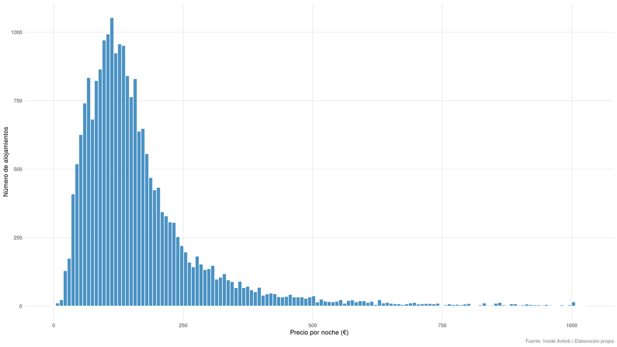

```r
ggplot(p_data, aes(x = price)) +
  geom_histogram(
    binwidth = 2 * IQR(p_data$price) / nrow(p_data)^(1/3),
    fill = "#2C7FB8",
    color = "white",
    alpha = 0.85
  ) +
  labs(
    x = "Precio por noche (€)",
    y = "Número de alojamientos",
    caption = "Fuente: Inside Airbnb | Elaboración propia"
  ) +
  theme_minimal(base_size = 12) +
  theme(
    plot.title = element_text(face = "bold", size = 15),
    plot.subtitle = element_text(color = "gray40", size = 11),
    plot.caption = element_text(color = "gray50", size = 9),
    panel.grid.minor = element_blank()
  )
```

La media y la mediana permiten evaluar el nivel general de precios. La comparación entre ambas resulta especialmente interesante porque los alojamientos turísticos pueden presentar precios extremadamente elevados que distorsionan la media. Esto es lo que ocurre con, al menos, el 1% de alojamientos (que están por encima de 1000 euros la noche) que se han excluido de la representación.